# Productos metálicos en CDMX — Análisis DENUE

## Visualizaciones

### Gráfica 1 — Establecimientos por alcaldía

**Mensaje:** *“Las manufacturas metálicas se concentran en Iztapalapa y Gustavo A. Madero.”*

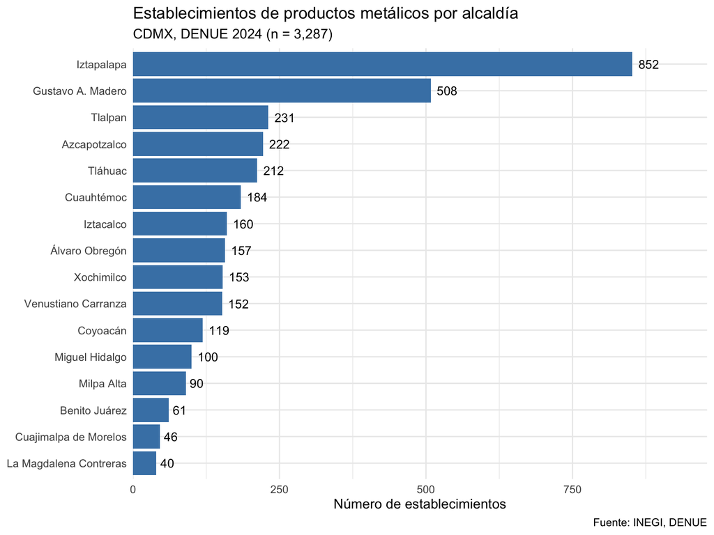

```r
denue %>%
  count(Municipio, sort = TRUE) %>%
  mutate(Municipio = reorder(Municipio, n)) %>%
  ggplot(aes(x = n, y = Municipio)) +
  geom_col(fill = "steelblue") +
  geom_text(aes(label = n), hjust = -0.3, size = 3.5) +
  scale_x_continuous(expand = expansion(mult = c(0, 0.15))) +
  labs(
    title    = "Establecimientos de productos metálicos por alcaldía",
    subtitle = "CDMX, DENUE 2024 (n = 3,287)",
    x        = "Número de establecimientos",
    y        = NULL,
    caption  = "Fuente: INEGI, DENUE"
  ) +
  theme_minimal()
```

**Lectura por elementos:**

- **Barras horizontales** → cada alcaldía.
- **Eje x** → número de establecimientos (con dato al final de cada barra).
- **Eje y** → alcaldía, ordenada de mayor a menor (Iztapalapa arriba).
- **Sin leyenda** → no hay variables categóricas adicionales; el color es solo decorativo.
- **Título + subtítulo** → responden “¿qué?” y “¿cuántos?” sin que el lector tenga que adivinar.

### Gráfica 2 — Distribución por tamaño (micro vs. PyME vs. grande)

**Mensaje:** *“El sector es predominantemente micro.”*

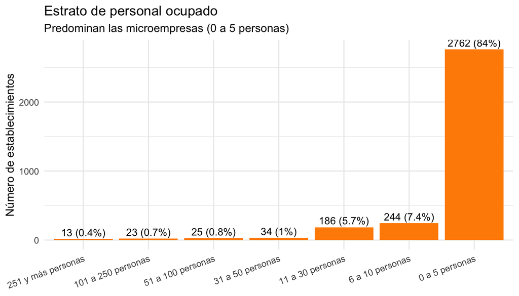

```r
denue %>%
  count(`Descripcion estrato personal ocupado`) %>%
  mutate(
    `Descripcion estrato personal ocupado` = reorder(
      `Descripcion estrato personal ocupado`, n
    ),
    pct = round(100 * n / sum(n), 1)
  ) %>%
  ggplot(aes(x = `Descripcion estrato personal ocupado`, y = n)) +
  geom_col(fill = "darkorange") +
  geom_text(aes(label = paste0(n, " (", pct, "%)")),
            vjust = -0.4, size = 3.5) +
  labs(
    title    = "Estrato de personal ocupado",
    subtitle = "Predominan las microempresas (0 a 5 personas)",
    x        = NULL,
    y        = "Número de establecimientos"
  ) +
  theme_minimal() +
  theme(axis.text.x = element_text(angle = 20, hjust = 1))
```

**Lectura por elementos:**

- **Eje x** → cada estrato (etiqueta clara: “0 a 5 personas”, etc.).
- **Eje y** → número de establecimientos.
- **Etiqueta encima de cada barra** → número exacto + porcentaje. **El lector puede señalar y decir qué significa cada elemento.**